# Time Series midterm exam

B082040005 高念慈

2023-05-14

## 1.

- 2022/1/3 ~ 2022/12/30
- 初始 100
- aapl 0.3
- intc 0.5
- msft 0.2
- 2023/1/3 to 2023/3/31
- aapl 0.2
- intc 0.2
- msft 0.6

```r
data_1 = read.csv("C:/Users/user/Desktop/time_series/HW/2023_midexam/data_1.csv",header=T)
head(data_1)
```

```
##         date     AAPL     INTC     MSFT
## 1 2022-01-03 180.6839 50.56260 330.8138
## 2 2022-01-04 178.3907 50.49609 325.1414
## 3 2022-01-05 173.6455 51.18977 312.6599
## 4 2022-01-06 170.7468 51.32280 310.1893
## 5 2022-01-07 170.9156 50.78115 310.3474
## 6 2022-01-10 170.9354 52.46309 310.5747
```

```r
AAPL_return = dailyReturn(ts(data_1[,2]))
INTC_return = dailyReturn(ts(data_1[,3]))
MSFT_return = dailyReturn(ts(data_1[,4]))

return_data = data.frame(AAPL_return, INTC_return, MSFT_return)

rownames(return_data) = as.Date(data_1[,1], format = "%Y-%m-%d")
colnames(return_data) = c('AAPL', 'INTC', 'MSFT')
```

1. What is the 4-period log-return of the portfolio from 2022-04-25 to 2022-04-29 ?

```r
portfolio_data = data.frame(data_1[1:251,1])
portfolio_data[, 2] = data_1[1:251,2]/data_1[1,2]*30
portfolio_data[, 3] = data_1[1:251,3]/data_1[1,3]*50
portfolio_data[, 4] = data_1[1:251,4]/data_1[1,4]*20
portfolio_data[, 5] = portfolio_data[,2] + portfolio_data[,3] + portfolio_data[4]

colnames(portfolio_data) = c('date', 'AAPL', 'INTC', 'MSFT', 'value')
log(portfolio_data[82,5]) - log(portfolio_data[78,5])
```

```
## [1] -0.05043428
```

```r
## -0.05043428
```

```r
a_data = return_data[79:82,]

log((prod(a_data[,1]+1)-1)*0.3 + (prod(a_data[,2]+1)-1)*0.5 + (prod (a_data[,3]+1)-1)*0.2 +1)
```

```
## [1] -0.05001056
```

```r
## -0.05001056
```

2. What is the average daily simple return of the portfolio from 2022-04-01 to 2022-04-29 ?

```r
b_data = return_data[63:82,]

(prod (b_data[,1]*0.3 + b_data[,2]*0.5 + b_data[,3]*0.2 + 1))^(1/length(b_data[,1]))-1
```

```
## [1] -0.005738161
```

```r
## -0.005738161
```

```r
(portfolio_data[82,5]/portfolio_data[63,5])^(1/length (b_data[,1]))-1
```

```
## [1] -0.005048979
```

```r
## -0.005048979
```

3. What is the cumulative simple return of the portfolio from 2022/1/3 to 2022/12/30 ?

```r
c_data = return_data[2:251,]
prod((c_data[,1])*0.3 + (c_data[,2])*0.5 + (c_data[,3])*0.2 + 1) - 1
```

```
## [1] -0.3829065
```

```r
## -0.3829065
```

```r
portfolio_data[251,5]/portfolio_data[1,5]-1
```

```
## [1] -0.38176
```

```r
## -0.38176
```

4. What is the cumulative log return of the portfolio from 2022/1/3 to 2023/3/31 ?

```r
portfolio_data_2 = data.frame(data_1[252:313,1])

portfolio_data_2[, 2] = data_1[252:313,2]/data_1[252,2]*portfolio_data[251,5]*0.2
portfolio_data_2[, 3] = data_1[252:313,3]/data_1[252,3]*portfolio_data[251,5] *0.2
portfolio_data_2[, 4] = data_1[252:313,4]/data_1[252,4] *portfolio_data[251,5]*0.6

portfolio_data_2[, 5] = portfolio_data_2[,2] + portfolio_data_2[,3] + portfolio_data_2[, 4]

log((portfolio_data[251,5]/portfolio_data[1,5])*(portfolio_data_2[62, 5]/portfolio_data_2[1,5]))
```

```
## [1] -0.2695324
```

```r
## -0.2695324
```

```r
d_data = return_data[252:313,]

c_return = prod((c_data[,1])*0.3 + (c_data[,2])*0.5 + (c_data[,3])*0.2 + 1)* prod((d_data[,1])*0.2 + (d_data[,2])*0.2 + (d_data[,3])*0.6 +1)

log(c_return)
```

```
## [1] -0.2744475
```

```r
## -0.2744475
```

## 2.

```r
data_2 = read.csv("C:/Users/user/Desktop/time_series/HW/2023_midexam/data_2.csv",header=T)
head(data_2)
```

```
##        date ten_years_rate three_years_rate
## 1  2003/5/6          3.788            1.888
## 2  2003/5/7          3.678            1.816
## 3  2003/5/8          3.454            1.829
## 4  2003/5/9          3.682            1.819
## 5 2003/5/12          3.639            1.797
## 6 2003/5/13          3.608            1.796
```

1. Build a regression model using ten_years_rate as the dependent variable and three_years_rate as independent variable. Perform the goodness of fit test on the residuals of the fitted model.

```r
m1 = lm(ten_years_rate~three_years_rate,data=data_2)
summary(m1)
```

```
##
## Call:
## lm(formula = ten_years_rate ~ three_years_rate, data = data_2)
##
## Residuals:
##     Min      1Q  Median      3Q     Max
## -1.3282 -0.4565 -0.1299  0.4910  1.3092
##
## Coefficients:
##                  Estimate Std. Error t value Pr(>|t|)
## (Intercept)       1.56804    0.01442   108.7   <2e-16 ***
## three_years_rate  0.71047    0.00650   109.3   <2e-16 ***
## ---
## Signif. codes:  0 '***' 0.001 '**' 0.01 '*' 0.05 '.' 0.1 ' ' 1
##
## Residual standard error: 0.6053 on 4638 degrees of freedom
## Multiple R-squared:  0.7203, Adjusted R-squared:  0.7203
## F-statistic: 1.195e+04 on 1 and 4638 DF,  p-value: < 2.2e-16
```

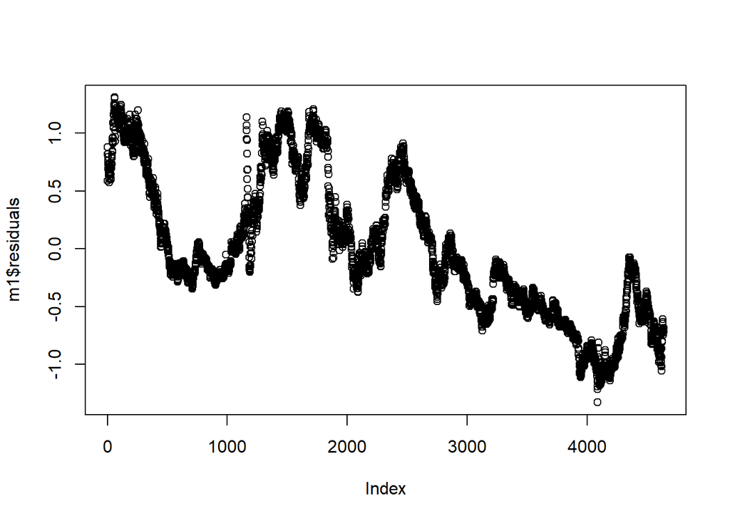

```r
plot(m1$residuals)
```

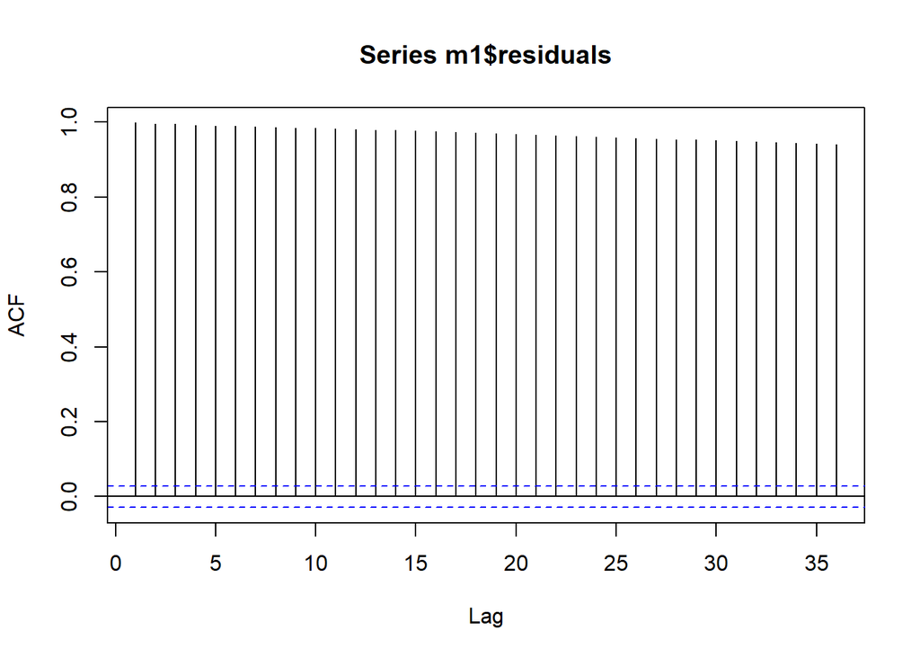

```r
acf(m1$residuals)
```

```r
Box.test(m1$residuals,lag=12)
```

```
##
##  Box-Pierce test
##
## data:  m1$residuals
## X-squared = 54405, df = 12, p-value < 2.2e-16
```

- p value<0.05，拒絕H0，序列相關，該模型不夠，(不好)
2. Build a regression model using the first difference of ten_years_rate as the dependent variable and the first difference of three_years_rate as independent variable. Perform the goodness of fit test on the residuals of the fitted regression model.

```r
c10 = diff(data_2$ten_years_rate)
c3 = diff(data_2$three_years_rate)

m2 = lm(c10~c3,data=data_2)
summary(m2)
```

```
##
## Call:
## lm(formula = c10 ~ c3, data = data_2)
##
## Residuals:
##      Min       1Q   Median       3Q      Max
## -0.26182 -0.01646 -0.00046  0.01591  0.77922
##
## Coefficients:
##               Estimate Std. Error t value Pr(>|t|)
## (Intercept) -0.0003607  0.0005245  -0.688    0.492
## c3           0.8179692  0.0101568  80.534   <2e-16 ***
## ---
## Signif. codes:  0 '***' 0.001 '**' 0.01 '*' 0.05 '.' 0.1 ' ' 1
##
## Residual standard error: 0.03572 on 4637 degrees of freedom
## Multiple R-squared:  0.5831, Adjusted R-squared:  0.583
## F-statistic:  6486 on 1 and 4637 DF,  p-value: < 2.2e-16
```

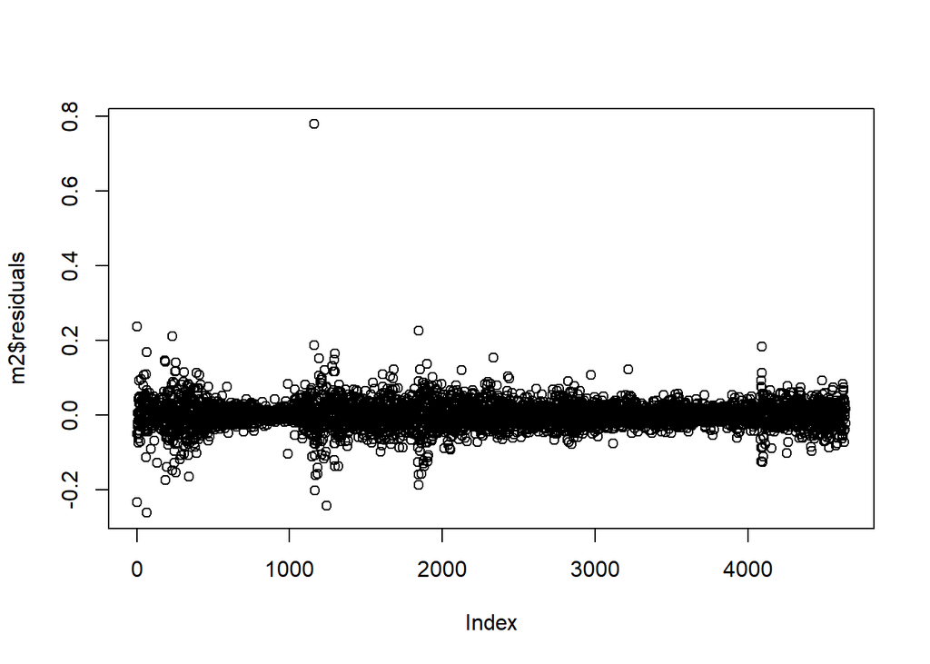

```r
plot(m2$residuals)
```

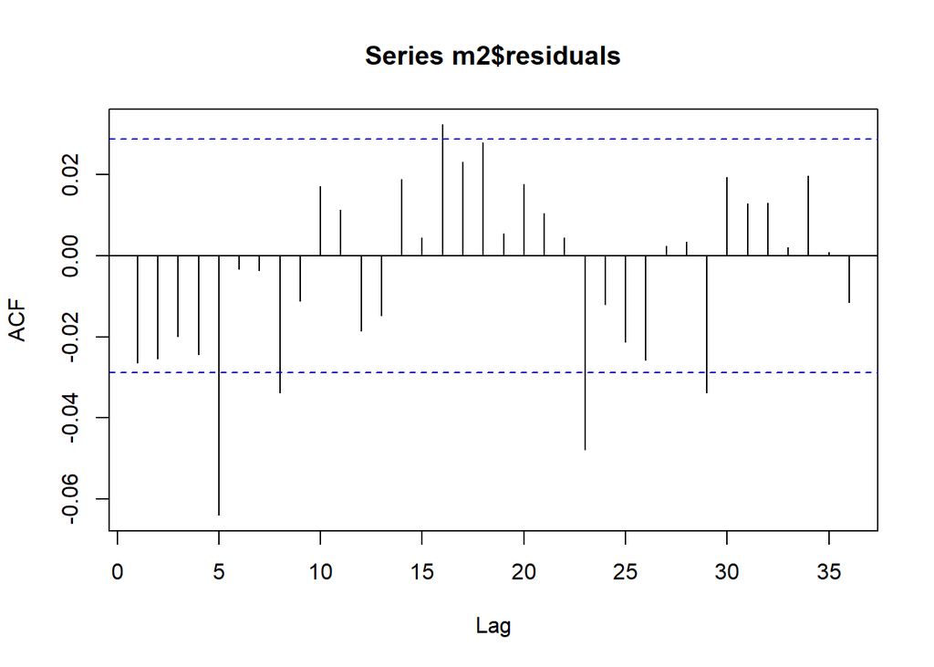

```r
acf(m2$residuals)
```

```r
Box.test(m2$residuals,lag=12)
```

```
##
##  Box-Pierce test
##
## data:  m2$residuals
## X-squared = 39.231, df = 12, p-value = 9.638e-05
```

- p value<0.05，拒絕H0，序列相關，該模型不夠，(不好)
3. Build a regression with time series error model using the first difference of ten_years_rate as the dependent variable and the first difference of three_years_rate as independent variable. Perform the goodness of fit test on the residuals of the fitted regression model
- 由ACF圖考慮error為MA(5)

```r
estmodel1 = arima(c10,order = c(0,0,5),xreg = c3,include.mean = F)
estmodel1
```

```
##
## Call:
## arima(x = c10, order = c(0, 0, 5), xreg = c3, include.mean = F)
##
## Coefficients:
##           ma1      ma2      ma3      ma4      ma5    xreg
##       -0.0310  -0.0297  -0.0275  -0.0298  -0.0657  0.8179
## s.e.   0.0147   0.0147   0.0148   0.0153   0.0145  0.0101
##
## sigma^2 estimated as 0.001266:  log likelihood = 8892.29,  aic = -17772.57
```

```r
rbind(estmodel1$coef-2*sqrt(diag(estmodel1$var.coef)),estmodel1$coef+2*sqrt(diag(estmodel1$var.coef)))
```

```
##               ma1           ma2          ma3           ma4         ma5
## [1,] -0.060353800 -0.0592141864 -0.057129771 -0.0604373803 -0.09465683
## [2,] -0.001670301 -0.0002464556  0.002179023  0.0009153795 -0.03671049
##           xreg
## [1,] 0.7977481
## [2,] 0.8381361
```

- 移掉 ma3 ma4

```r
m3 = arima(c10,
           order = c(0,0,5),
           fixed = c(NA,NA,0,0,NA,NA),
           xreg = c3,
           include.mean = F)
m3
```

```
##
## Call:
## arima(x = c10, order = c(0, 0, 5), xreg = c3, include.mean = F, fixed = c(NA,
##     NA, 0, 0, NA, NA))
##
## Coefficients:
##           ma1      ma2  ma3  ma4      ma5    xreg
##       -0.0314  -0.0317    0    0  -0.0656  0.8164
## s.e.   0.0147   0.0152    0    0   0.0145  0.0101
##
## sigma^2 estimated as 0.001268:  log likelihood = 8888.61,  aic = -17769.21
```

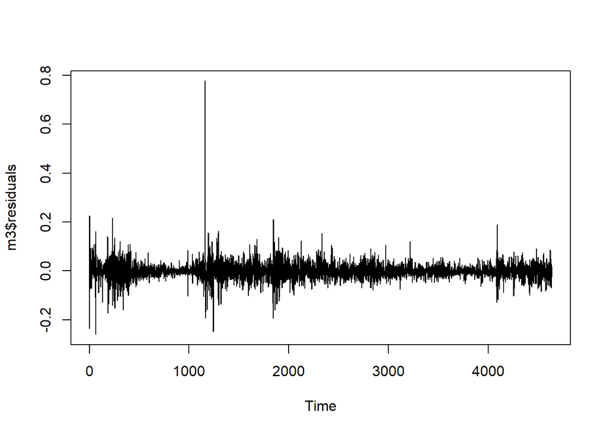

```r
plot(m3$residuals)
```